# AdaBoosting Algorithm from scratch

### Boosting

Boosting algorithms are a set of the weak classifiers to create a strong classifier.

Strong classifiers offer error rate close to 0.

Boosting algorithm can track the model who failed the accurate prediction.

Boosting algorithms are less affected by the overfitting problem.

The following three algorithms have gained massive popularity in data science competitions.

```
AdaBoost (Adaptive Boosting)
Gradient Tree Boosting (GBM)
XGBoost
```

AdaBoost or Adaptive Boosting is one of the ensemble boosting classifier proposed by Yoav Freund and Robert Schapire in 1996.

It combines multiple weak classifiers to increase the accuracy of classifiers.

AdaBoost is an iterative ensemble method. AdaBoost classifier builds a strong classifier by combining multiple poorly performing classifiers so that you will get high accuracy strong classifier.

The basic concept behind Adaboost is to set the weights of classifiers and training the data sample in each iteration such that it ensures the accurate predictions of unusual observations.

Below are the steps for performing the AdaBoost algorithm:

```
1. Initially, Adaboost selects a training subset randomly.

2. It iteratively trains the AdaBoost machine learning model by selecting the training set based on the accurate prediction of the last training.

3. It assigns the higher weight to wrong classified observations so that in the next iteration these observations will get the high probability for classification.

4. Also, It assigns the weight to the trained classifier in each iteration according to the accuracy of the classifier. The more accurate classifier will get high weight.

5. This process iterate until the complete training data fits without any error or until reached to the specified maximum number of estimators.

6. To classify, perform a "vote" across all of the learning algorithms you built.
```

The intuition can be depicted with the following diagram:

```python
from IPython.display import Image
from IPython.core.display import HTML
Image(url= "https://upload.wikimedia.org/wikipedia/commons/thumb/b/b5/Ensemble_Boosting.svg/2560px-Ensemble_Boosting.svg.png")
```

[figure not shown]

```python
#importing libraries

import numpy as np
import pandas as pd
import matplotlib.pyplot as plt
from random import sample
import random
from sklearn.tree import DecisionTreeClassifier
from sklearn.metrics import confusion_matrix
from sklearn import tree
from math import log,exp
```

```python
#importing file
df = pd.read_csv("adaboost_wikidata.csv")
```

```python
df
```

|  | CreditRisk | Savings | Assets | Income |
| --- | --- | --- | --- | --- |
| 0 | Good | Medium | High | 75000 |
| 1 | Bad | Low | Low | 50000 |
| 2 | Bad | High | Medium | 25000 |
| 3 | Good | Medium | Medium | 50000 |
| 4 | Good | Low | Medium | 100000 |
| 5 | Good | High | High | 25000 |
| 6 | Bad | Low | Low | 25000 |
| 7 | Good | Medium | Medium | 75000 |

```python
from sklearn.preprocessing import LabelEncoder
le = LabelEncoder()
df[['CreditRisk','Savings','Assets']] = df[['CreditRisk','Savings','Assets']].apply(le.fit_transform)
df
```

|  | CreditRisk | Savings | Assets | Income |
| --- | --- | --- | --- | --- |
| 0 | 1 | 2 | 0 | 75000 |
| 1 | 0 | 1 | 1 | 50000 |
| 2 | 0 | 0 | 2 | 25000 |
| 3 | 1 | 2 | 2 | 50000 |
| 4 | 1 | 1 | 2 | 100000 |
| 5 | 1 | 0 | 0 | 25000 |
| 6 | 0 | 1 | 1 | 25000 |
| 7 | 1 | 2 | 2 | 75000 |

```python
#Initially assign same weights to each records in the dataset
df['probR1'] = 1/(df.shape[0])
```

```python
df
```

|  | CreditRisk | Savings | Assets | Income | probR1 |
| --- | --- | --- | --- | --- | --- |
| 0 | 1 | 2 | 0 | 75000 | 0.125 |
| 1 | 0 | 1 | 1 | 50000 | 0.125 |
| 2 | 0 | 0 | 2 | 25000 | 0.125 |
| 3 | 1 | 2 | 2 | 50000 | 0.125 |
| 4 | 1 | 1 | 2 | 100000 | 0.125 |
| 5 | 1 | 0 | 0 | 25000 | 0.125 |
| 6 | 0 | 1 | 1 | 25000 | 0.125 |
| 7 | 1 | 2 | 2 | 75000 | 0.125 |

```python
X = df.iloc[:,1:]
y = df.iloc[:,0]
```

```python
X
```

|  | Savings | Assets | Income | probR1 |
| --- | --- | --- | --- | --- |
| 0 | 2 | 0 | 75000 | 0.125 |
| 1 | 1 | 1 | 50000 | 0.125 |
| 2 | 0 | 2 | 25000 | 0.125 |
| 3 | 2 | 2 | 50000 | 0.125 |
| 4 | 1 | 2 | 100000 | 0.125 |
| 5 | 0 | 0 | 25000 | 0.125 |
| 6 | 1 | 1 | 25000 | 0.125 |
| 7 | 2 | 2 | 75000 | 0.125 |

```python
y
```

```
0    1
1    0
2    0
3    1
4    1
5    1
6    0
7    1
Name: CreditRisk, dtype: int64
```

```python
from sklearn.tree import DecisionTreeClassifier
D_stump = DecisionTreeClassifier(criterion = "gini", random_state = 1, max_depth=1)
model = D_stump.fit(X, y)
```

```
[Text(0.5, 0.75, 'X[0] <= 1.5\ngini = 0.469\nsamples = 8\nvalue = [3, 5]'),
```

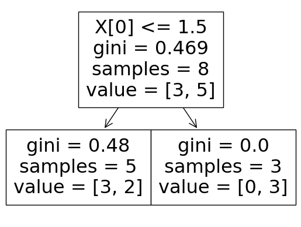

```python
#plotting tree for round 1 boosting
tree.plot_tree(model)
```

```python
#prediction
y_pred = D_stump.predict(X)
y_pred
```

```
array([1, 0, 0, 1, 0, 0, 0, 1])
```

```python
#adding a column pred1 after the first round of boosting
df['predicted1'] = y_pred
```

```python
df
```

|  | CreditRisk | Savings | Assets | Income | probR1 | predicted1 |
| --- | --- | --- | --- | --- | --- | --- |
| 0 | 1 | 2 | 0 | 75000 | 0.125 | 1 |
| 1 | 0 | 1 | 1 | 50000 | 0.125 | 0 |
| 2 | 0 | 0 | 2 | 25000 | 0.125 | 0 |
| 3 | 1 | 2 | 2 | 50000 | 0.125 | 1 |
| 4 | 1 | 1 | 2 | 100000 | 0.125 | 0 |
| 5 | 1 | 0 | 0 | 25000 | 0.125 | 0 |
| 6 | 0 | 1 | 1 | 25000 | 0.125 | 0 |
| 7 | 1 | 2 | 2 | 75000 | 0.125 | 1 |

```python
#misclassified = 0 if the label and prediction are same
df.loc[df.CreditRisk != df.predicted1, 'misclassified'] = 1
df.loc[df.CreditRisk == df.predicted1, 'misclassified'] = 0
```

```python
#error calculation
e1 = sum(df['misclassified'] * df['probR1'])
```

```python
e1
```

```
0.25
```

```python
#calculation of Amount of say [alpha (performance)]
alpha1 = 0.5*log((1-e1)/e1)
alpha1
```

```
0.5493061443340549
```

### Boosting will increase weight for misclassified samples in the follow-up tree

```python
# Update weights
def update_row_weights(row,alpha=alpha1):
    if row['CreditRisk'] == row['predicted1']:
        return row['probR1'] * np.exp(-alpha)
    else:
        return row['probR1'] * np.exp(alpha)
```

```python
df['new_weight'] = df.apply(update_row_weights,axis=1)
```

```python
df
```

|  | CreditRisk | Savings | Assets | Income | probR1 | predicted1 | misclassified | new_weight |
| --- | --- | --- | --- | --- | --- | --- | --- | --- |
| 0 | 1 | 2 | 0 | 75000 | 0.125 | 1 | 0.0 | 0.072169 |
| 1 | 0 | 1 | 1 | 50000 | 0.125 | 0 | 0.0 | 0.072169 |
| 2 | 0 | 0 | 2 | 25000 | 0.125 | 0 | 0.0 | 0.072169 |
| 3 | 1 | 2 | 2 | 50000 | 0.125 | 1 | 0.0 | 0.072169 |
| 4 | 1 | 1 | 2 | 100000 | 0.125 | 0 | 1.0 | 0.216506 |
| 5 | 1 | 0 | 0 | 25000 | 0.125 | 0 | 1.0 | 0.216506 |
| 6 | 0 | 1 | 1 | 25000 | 0.125 | 0 | 0.0 | 0.072169 |
| 7 | 1 | 2 | 2 | 75000 | 0.125 | 1 | 0.0 | 0.072169 |

```python
df['probR2'] = df['new_weight']/df['new_weight'].sum()
df
```

|  | CreditRisk | Savings | Assets | Income | probR1 | predicted1 | misclassified | new_weight | probR2 |
| --- | --- | --- | --- | --- | --- | --- | --- | --- | --- |
| 0 | 1 | 2 | 0 | 75000 | 0.125 | 1 | 0.0 | 0.072169 | 0.083333 |
| 1 | 0 | 1 | 1 | 50000 | 0.125 | 0 | 0.0 | 0.072169 | 0.083333 |
| 2 | 0 | 0 | 2 | 25000 | 0.125 | 0 | 0.0 | 0.072169 | 0.083333 |
| 3 | 1 | 2 | 2 | 50000 | 0.125 | 1 | 0.0 | 0.072169 | 0.083333 |
| 4 | 1 | 1 | 2 | 100000 | 0.125 | 0 | 1.0 | 0.216506 | 0.250000 |
| 5 | 1 | 0 | 0 | 25000 | 0.125 | 0 | 1.0 | 0.216506 | 0.250000 |
| 6 | 0 | 1 | 1 | 25000 | 0.125 | 0 | 0.0 | 0.072169 | 0.083333 |
| 7 | 1 | 2 | 2 | 75000 | 0.125 | 1 | 0.0 | 0.072169 | 0.083333 |

```python
#round 2
random.seed(20)
df2 = df.sample(len(df), replace = True, weights = df['probR2'])
df2 = df2.iloc[:,[0,1,2,3,8]]
X = df2.iloc[0:len(df),1:5]
y = df2.iloc[0:len(df),0]
```

```python
X
```

|  | Savings | Assets | Income | probR2 |
| --- | --- | --- | --- | --- |
| 5 | 0 | 0 | 25000 | 0.250000 |
| 5 | 0 | 0 | 25000 | 0.250000 |
| 5 | 0 | 0 | 25000 | 0.250000 |
| 4 | 1 | 2 | 100000 | 0.250000 |
| 6 | 1 | 1 | 25000 | 0.083333 |
| 5 | 0 | 0 | 25000 | 0.250000 |
| 3 | 2 | 2 | 50000 | 0.083333 |
| 1 | 1 | 1 | 50000 | 0.083333 |

[output not shown]

So that is how the errors that the first tree makes influence how the second tree is made… and the errors that the second tree makes influence how the third tree is made, … and so on

```python
clf_gini = DecisionTreeClassifier(criterion = "gini", random_state = 100, max_depth=1)
clf = clf_gini.fit(X, y)

y_pred = clf_gini.predict(df2.iloc[0:len(df2),1:5])
#adding a column pred2 after the second round of boosting
df2['pred2'] = y_pred
```

```python
df2
```

|  | CreditRisk | Savings | Assets | Income | probR2 | pred2 |
| --- | --- | --- | --- | --- | --- | --- |
| 5 | 1 | 0 | 0 | 25000 | 0.250000 | 1 |
| 5 | 1 | 0 | 0 | 25000 | 0.250000 | 1 |
| 5 | 1 | 0 | 0 | 25000 | 0.250000 | 1 |
| 4 | 1 | 1 | 2 | 100000 | 0.250000 | 1 |
| 6 | 0 | 1 | 1 | 25000 | 0.083333 | 0 |
| 5 | 1 | 0 | 0 | 25000 | 0.250000 | 1 |
| 3 | 1 | 2 | 2 | 50000 | 0.083333 | 0 |
| 1 | 0 | 1 | 1 | 50000 | 0.083333 | 0 |

```
[Text(0.5, 0.75, 'X[3] <= 0.167\ngini = 0.375\nsamples = 8\nvalue = [2, 6]'),
```

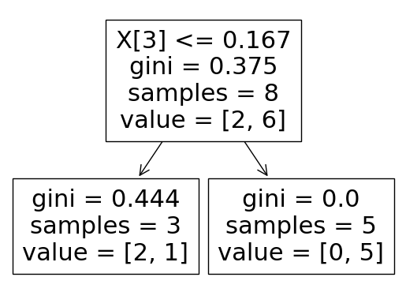

```python
#plotting tree for round 2 boosting
tree.plot_tree(clf)
```

```python
#misclassified = 0 if the label and prediction are same
df2.loc[df2.CreditRisk != df2.pred2, 'misclassified'] = 1
df2.loc[df2.CreditRisk == df2.pred2, 'misclassified'] = 0
#error calculation
e2 = sum(df2['misclassified'] * df2['probR2'])
e2
```

```
0.08333333333333333
```

```python
#calculation of Amount of say [alpha (performance)]
alpha2 = 0.5*log((1-e2)/e2)
alpha2
```

```
1.1989476363991853
```

```python
# Update weights
def update_row_weights2(row,alpha=alpha2):
    if row['CreditRisk'] == row['pred2']:
        return row['probR2'] * np.exp(-alpha)
    else:
        return row['probR2'] * np.exp(alpha)
```

```python
df2['new_weight'] = df2.apply(update_row_weights2,axis=1)
df2
```

|  | CreditRisk | Savings | Assets | Income | probR2 | pred2 | misclassified | new_weight |
| --- | --- | --- | --- | --- | --- | --- | --- | --- |
| 5 | 1 | 0 | 0 | 25000 | 0.250000 | 1 | 0.0 | 0.075378 |
| 5 | 1 | 0 | 0 | 25000 | 0.250000 | 1 | 0.0 | 0.075378 |
| 5 | 1 | 0 | 0 | 25000 | 0.250000 | 1 | 0.0 | 0.075378 |
| 4 | 1 | 1 | 2 | 100000 | 0.250000 | 1 | 0.0 | 0.075378 |
| 6 | 0 | 1 | 1 | 25000 | 0.083333 | 0 | 0.0 | 0.025126 |
| 5 | 1 | 0 | 0 | 25000 | 0.250000 | 1 | 0.0 | 0.075378 |
| 3 | 1 | 2 | 2 | 50000 | 0.083333 | 0 | 1.0 | 0.276385 |
| 1 | 0 | 1 | 1 | 50000 | 0.083333 | 0 | 0.0 | 0.025126 |

```python
df2['probR3'] = df2['new_weight']/df2['new_weight'].sum()
df2
```

|  | CreditRisk | Savings | Assets | Income | probR2 | pred2 | misclassified | new_weight | probR3 |
| --- | --- | --- | --- | --- | --- | --- | --- | --- | --- |
| 5 | 1 | 0 | 0 | 25000 | 0.250000 | 1 | 0.0 | 0.075378 | 0.107143 |
| 5 | 1 | 0 | 0 | 25000 | 0.250000 | 1 | 0.0 | 0.075378 | 0.107143 |
| 5 | 1 | 0 | 0 | 25000 | 0.250000 | 1 | 0.0 | 0.075378 | 0.107143 |
| 4 | 1 | 1 | 2 | 100000 | 0.250000 | 1 | 0.0 | 0.075378 | 0.107143 |
| 6 | 0 | 1 | 1 | 25000 | 0.083333 | 0 | 0.0 | 0.025126 | 0.035714 |
| 5 | 1 | 0 | 0 | 25000 | 0.250000 | 1 | 0.0 | 0.075378 | 0.107143 |
| 3 | 1 | 2 | 2 | 50000 | 0.083333 | 0 | 1.0 | 0.276385 | 0.392857 |
| 1 | 0 | 1 | 1 | 50000 | 0.083333 | 0 | 0.0 | 0.025126 | 0.035714 |

```python
#round 3
random.seed(15)
df3 = df2.sample(len(df2), replace = True, weights = df2['probR3'])
df3 = df3.iloc[:,[0,1,2,3,8]]
X = df3.iloc[0:len(df),1:5]
y = df3.iloc[0:len(df),0]
```

```python
X
```

|  | Savings | Assets | Income | probR3 |
| --- | --- | --- | --- | --- |
| 5 | 0 | 0 | 25000 | 0.107143 |
| 3 | 2 | 2 | 50000 | 0.392857 |
| 3 | 2 | 2 | 50000 | 0.392857 |
| 1 | 1 | 1 | 50000 | 0.035714 |
| 5 | 0 | 0 | 25000 | 0.107143 |
| 5 | 0 | 0 | 25000 | 0.107143 |
| 3 | 2 | 2 | 50000 | 0.392857 |
| 5 | 0 | 0 | 25000 | 0.107143 |

```python
y
```

```
5    1
3    1
3    1
1    0
5    1
5    1
3    1
5    1
Name: CreditRisk, dtype: int64
```

```python
clf_gini = DecisionTreeClassifier(criterion = "gini", random_state = 100, max_depth=1)
clf = clf_gini.fit(X, y)

y_pred = clf_gini.predict(X)
#adding a column pred2 after the second round of boosting
df3['pred3'] = y_pred
```

```python
y_pred
```

```
array([1, 1, 1, 0, 1, 1, 1, 1])
```

```python
#Confusion matrix
c=confusion_matrix(df3['CreditRisk'], df3['pred3'])
c
```

```
array([[1, 0],
       [0, 7]])
```

```python
#Overall Accuracy
(c[0,0]+c[1,1])/np.sum(c)*100
```

```
100.0
```

```python
#Fitting the model using the adaboost classifier library
```

```python
from sklearn.ensemble import AdaBoostClassifier
```

```python
df = pd.read_csv("adaboost_wikidata.csv")
df
```

|  | CreditRisk | Savings | Assets | Income |
| --- | --- | --- | --- | --- |
| 0 | Good | Medium | High | 75000 |
| 1 | Bad | Low | Low | 50000 |
| 2 | Bad | High | Medium | 25000 |
| 3 | Good | Medium | Medium | 50000 |
| 4 | Good | Low | Medium | 100000 |
| 5 | Good | High | High | 25000 |
| 6 | Bad | Low | Low | 25000 |
| 7 | Good | Medium | Medium | 75000 |

```python
from sklearn.preprocessing import LabelEncoder
le = LabelEncoder()
df[['CreditRisk','Savings','Assets']] = df[['CreditRisk','Savings','Assets']].apply(le.fit_transform)
df
```

|  | CreditRisk | Savings | Assets | Income |
| --- | --- | --- | --- | --- |
| 0 | 1 | 2 | 0 | 75000 |
| 1 | 0 | 1 | 1 | 50000 |
| 2 | 0 | 0 | 2 | 25000 |
| 3 | 1 | 2 | 2 | 50000 |
| 4 | 1 | 1 | 2 | 100000 |
| 5 | 1 | 0 | 0 | 25000 |
| 6 | 0 | 1 | 1 | 25000 |
| 7 | 1 | 2 | 2 | 75000 |

```python
#X_train and Y_train split
X = df.iloc[0:len(df),1:4]
y = df.iloc[0:len(df),0]
```

```python
clf = AdaBoostClassifier(n_estimators=3, random_state=0)
clf.fit(X, y)
```

```
AdaBoostClassifier(n_estimators=3, random_state=0)
```

```python
y_pred = clf.predict(X)
```

```python
c=confusion_matrix(df['CreditRisk'], y_pred)
c
```

```
array([[3, 0],
       [0, 5]])
```

Finally, Now we need to talk about how a forest of stumps created by AdaBoost makes classification.

Imagine there are 3 stumps are created by the AdaBoost algorithm. Out of 3 stumps, 2 stumps are classified credit risk is good, and the other 1 stumps classified credit risk is Bad.

Caliculate the total Amount of Say for these stumps classied as credit risk good and the total Amount of Say of the other stumps classied as credit risk Bad.

Finally the customer will be classified as Good or Bad based on toal amont of say value which ever is maximum.